# TD ISS

Laurent Politis

28/04/2021

## API (Application programming interface)

En informatique, une interface de programmation applicative (souvent désignée par le terme API pour application programming interface) est un ensemble normalisé de classes, de méthodes ou de fonctions qui sert de façade par laquelle un logiciel offre des services à d’autres logiciels. Elle est offerte par une bibliothèque logicielle ou un service web, le plus souvent accompagnée d’une description qui spécifie comment des programmes consommateurs peuvent se servir des fonctionnalités du programme fournisseur.

Dans l’industrie contemporaine du logiciel, les applications informatiques se servent de nombreuses interfaces de programmation, la programmation se fait en réutilisant des briques de fonctionnalités fournies par des logiciels tiers. Cette construction par assemblage nécessite pour le programmeur de connaître la manière d’interagir avec les autres logiciels, qui dépend de leur interface de programmation. Le programmeur n’a pas besoin de connaître les détails de la logique interne du logiciel tiers, et celle-ci n’est généralement pas documentée par le fournisseur.

Des logiciels tels que les systèmes d’exploitation, les systèmes de gestion de base de données, les langages de programmation, ou les serveurs d’applications comportent une interface de programmation.

## Exemple d’une API

“The International Space Station is moving at close to 28,000 km/h so its location changes really fast! Where is it right now?”

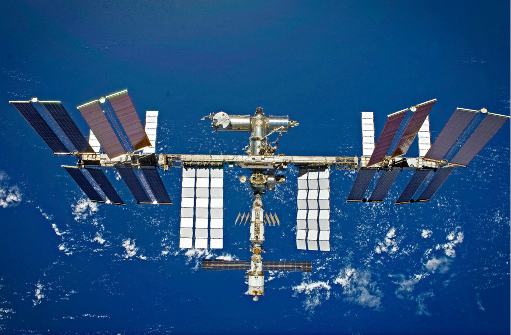

Nous allons chercher les cordonnées spatiales de la station ISS :

- Première étape: Chercher un json indiquant la position de la station
- Seconde étape: convertir se JSON en data frame
- Troisième étape: créer une carte interactive avec leaflet permettant de voir la position de la station
1. Rechercher l’api qui permet de récupérer la position de la station via votre explorateur web préféré
2. Une fois l’API trouvée vous allez pouvoir télécharger à l’aide de R la position de l’ISS. Installer pour cela le package htrr, qui permet de manipuler les fichier JSON.
3. Utiliser la fonction`httr::GET()` afin de récupérer le fichier JSON de la requête, puis la fonction `httr::content()`,qui comme son nom l’indique vous donne le contenu du fichier Json.

   ```
   ## Response [http://api.open-notify.org/iss-now.json]
   ##   Date: 2021-04-28 21:24
   ##   Status: 200
   ##   Content-Type: application/json
   ##   Size: 114 B
   ```

4. Quelle est la classe de l’objet que vous avez récupéré ?

5. Transformer cet objet en data frame à l’aide de la fonction `as.data.frame().`

   ```
   ##    timestamp message iss_position.longitude iss_position.latitude
   ## 1 1619645051 success              -131.0345               -0.6733
   ```

6. Dessiner la position actuelle de la station ISS sur le globe terrestre.

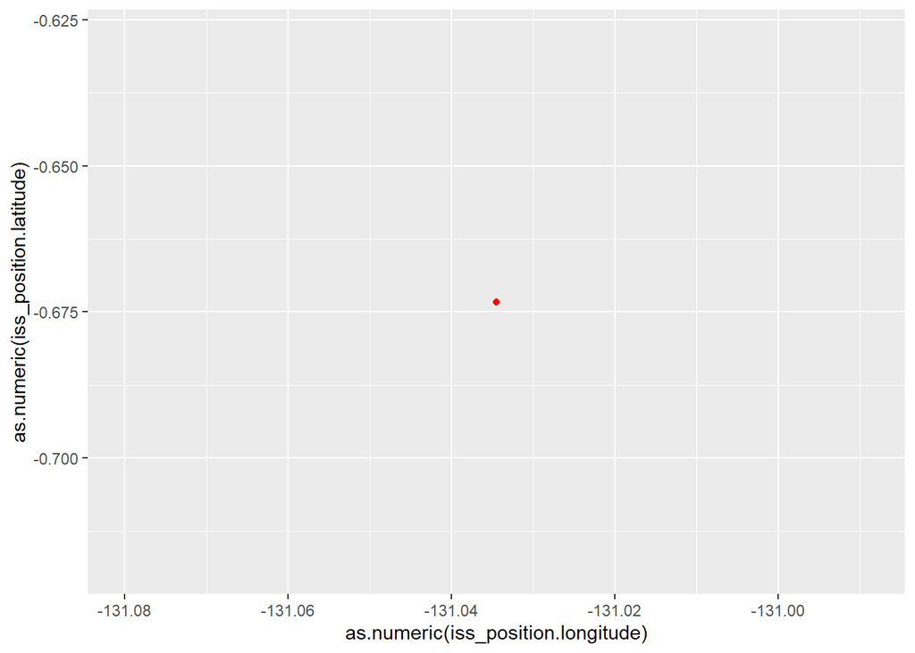

Un graphique un peu plus avancé avec la fonction `geom_quickmap()` & `geom_polygon()`

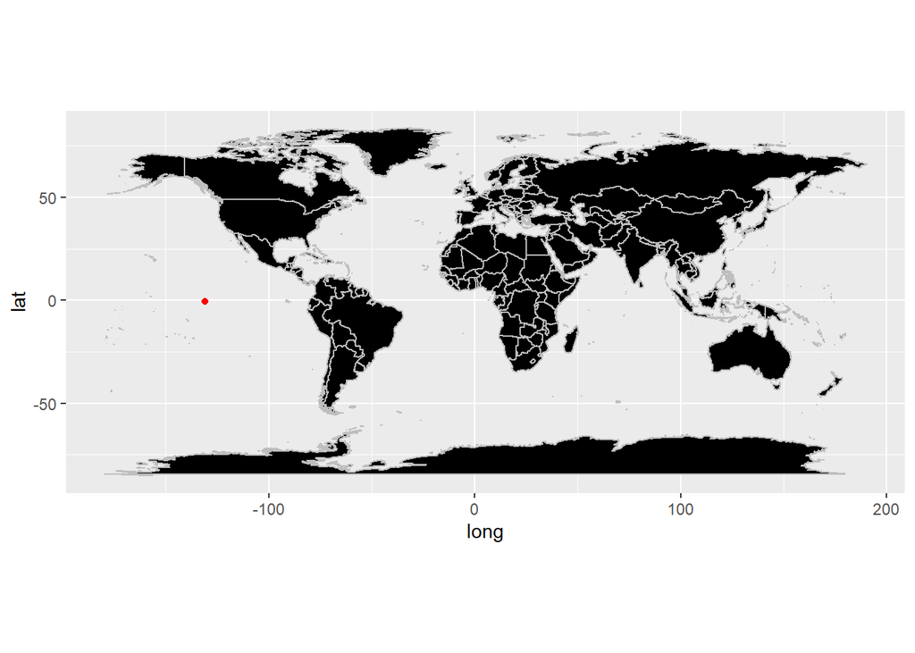

#### Trajectoire

Nous allons télécharger les positions de la station toutes les 10 secondes dans le but de “dessiner” sa trajectoire sur le globe.

Pour stocker les résultats de la requête nous allons enregistrer cette data frame sous un format csv.

Après, le package GGplot2 va nous permettre de faire un graphe sur le globe de la position de la station ISS.

Enfin, écrivez une boucle for afin pouvoir faire plusieurs requêtes du même type.

[figure not shown]

```r
library(ggplot2)
library(readr)

df <- read_csv("position.csv")
```

Un graphique un peu plus avancé avec la fonction `geom_quickmap()` & `geom_polygon()`

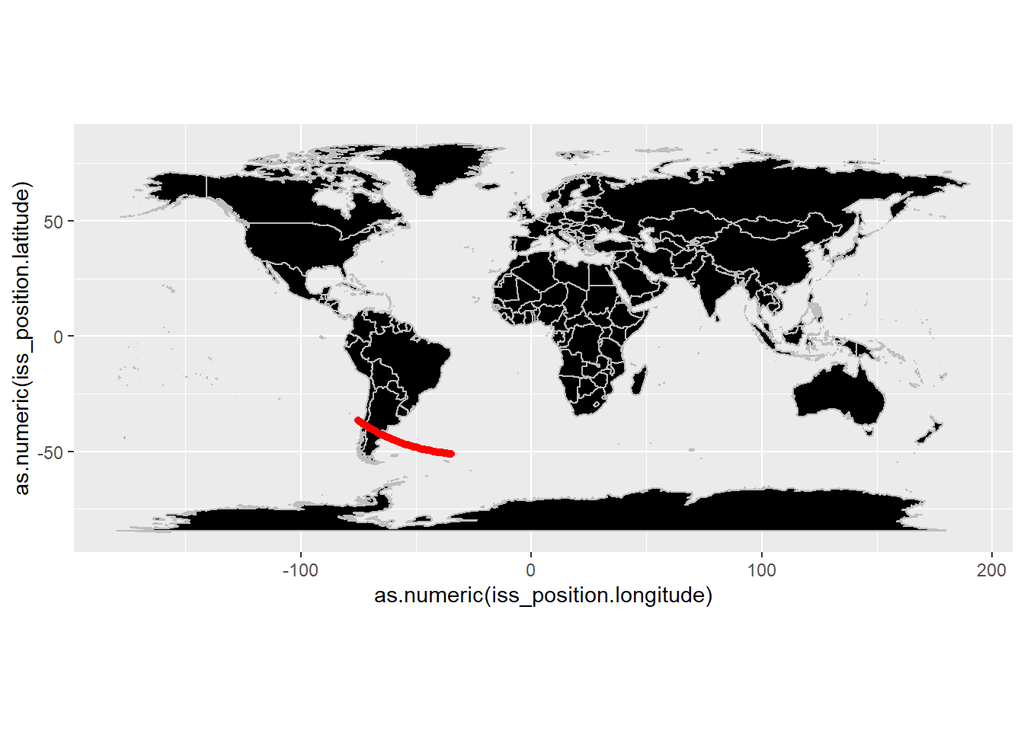

### Animation

Avec la fonction du paquet `gganimate::transition_time()`

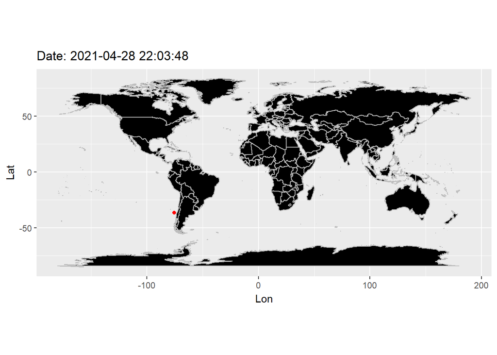

```r
library(gganimate)
p+  transition_time(date)+
  labs(title = "Date: {frame_time}",
       x="Lon",
       y="Lat")
```